# German Credit

Elijah Verdoorn

November 3, 2016

# Set Up

```r
library(dplyr)
library(glmnet)
```

```r
library(ggplot2)
library(glmnet)
library(MASS)
library(class)

# Cost Matrix
costFalsePositive <- 5
costFalseNegative <- 1
costTrueNegative <- 0
costTruePositive <- 0

germanCreditNumeric.df <- read.csv("germanNumeric.csv", header = T) # read the numeric data
germanCredit.df <- read.csv("german.csv", header = F, sep = "") # read the original data
names(germanCredit.df) <- c("chk_ac_status_1",
                            "duration_month_2", "credit_history_3", "purpose_4",
                            "credit_amount_5","savings_ac_bond_6","p_employment_since_7",
                            "instalment_pct_8", "personal_status_9","other_debtors_or_grantors_10",
                            "present_residence_since_11","property_type_12","age_in_yrs_13",
                            "other_instalment_type_14", "housing_type_15",
                            "number_cards_this_bank_16","job_17","no_people_liable_for_mntnance_18",
                            "telephone_19", "foreign_worker_20",
                            "good_bad_21")

# the data comes with the response variable as a 1 or 2, I want T or F
germanCredit.df <- germanCredit.df %>%
  mutate(good_bad_21 = ifelse(germanCredit.df["good_bad_21"] == 1, F, T))


germanCreditNumeric.df <- germanCreditNumeric.df %>% # add the response variable to the numeric data
    mutate(response = germanCredit.df[,21])
```

This section gets the set-up going, grabs the data and defines some constants

```r
# get the data into the form that we want it in
# 75% of the sample size
sampleSizeNumeric <- floor(0.75 * nrow(germanCreditNumeric.df))
sampleSize <- floor(0.75 * nrow(germanCredit.df))
trainIndexNumeric <- sample(seq_len(nrow(germanCreditNumeric.df)), size = sampleSizeNumeric)
trainIndex <- sample(seq_len(nrow(germanCredit.df)), size = sampleSize)
train <- mtcars[trainIndex, ]
test <- mtcars[-trainIndex, ]

numericTest.df <- germanCreditNumeric.df[trainIndexNumeric,]
numericTrain.df <- germanCreditNumeric.df[-trainIndexNumeric,]

numericTest.mat <- data.matrix(numericTest.df)
numericTrain.mat <- data.matrix(numericTrain.df)

germanTest.df <- germanCredit.df[trainIndex,]
germanTrain.df <- germanCredit.df[-trainIndex,]
```

This section uses a sampler to grab a portion of the data for testing and another portion for training.

# Lasso

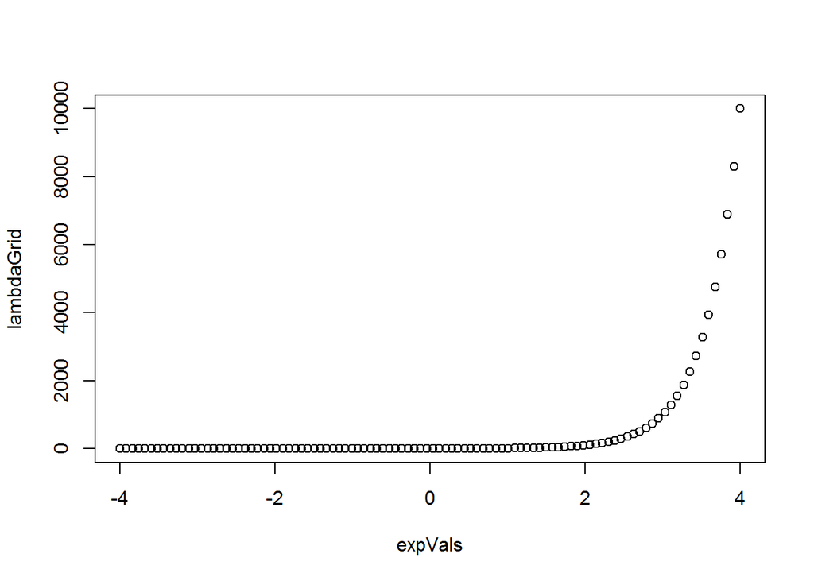

```r
# build the matrices of variables in the format that glmnet wants
xNumericTrain.mat <- data.matrix(numericTrain.df[,1:49])
yNumericTrain.mat <- data.matrix(numericTrain.df[,50])
xNumericTest.mat <- data.matrix(numericTest.df[,1:49])
yNumericTest.mat <- data.matrix(numericTest.df[,50])

# want a "grid" of lambda vals so that we can pick an ideal lambda
numLambda <- 100
expVals <- seq(-4, 4, length = numLambda)
lambdaGrid <- 10^expVals
plot(expVals, lambdaGrid) # make sure that it looks exponential
```

This plot is the graph of the lambda values, which we use to verify that the lambdas are of the form that we want.

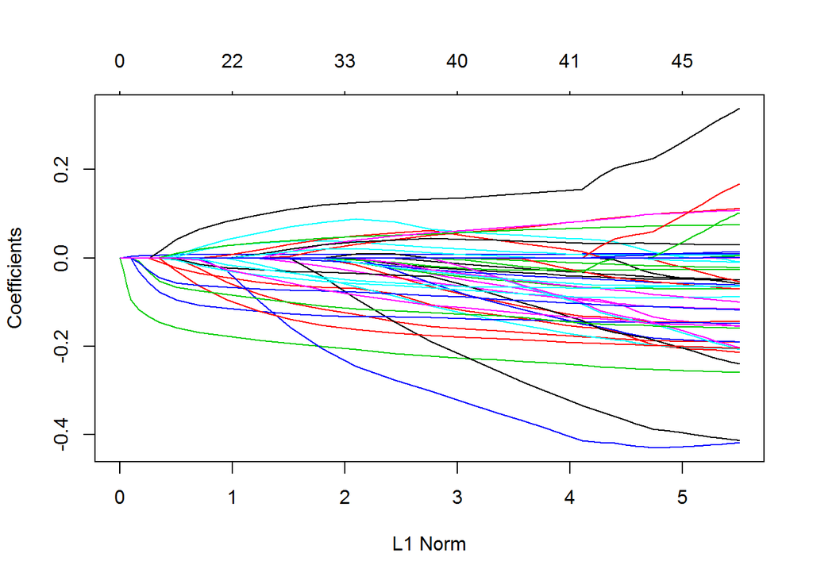

```r
lassoModel <- glmnet(xNumericTrain.mat, yNumericTrain.mat, alpha = 1, lambda = lambdaGrid, intercept = TRUE) # use the lambdas that we just made to find the ideal value
# coef(lassoModel) # look at the coefficients of the model
plot(lassoModel) # see what the model looks like
```

A plot of the lasso model

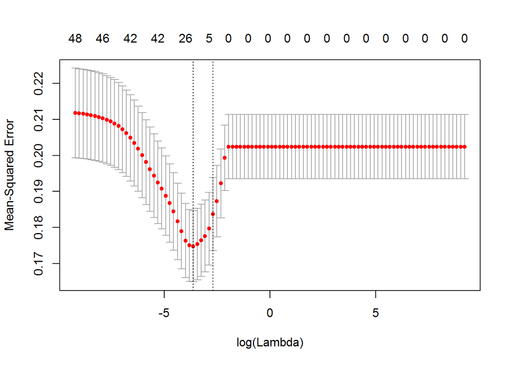

```r
# get the optimal lambda
crossValidatedLassoModel <- cv.glmnet(xNumericTrain.mat, yNumericTrain.mat, alpha = 1, lambda = lambdaGrid, intercept = TRUE) # cross validate
plot(crossValidatedLassoModel) # plot the model
```

```r
(lambda0 <- crossValidatedLassoModel$lambda.min)
```

```
## [1] 0.02656088
```

```r
(lambda1 <- crossValidatedLassoModel$lambda.1se)
```

```
## [1] 0.06734151
```

```r
mod.lasso <- glmnet(xNumericTrain.mat, yNumericTrain.mat, alpha = 1, lambda = lambda0, intercept = TRUE) # use the optimal lambda

mod.lassoConservative <- glmnet(xNumericTrain.mat, yNumericTrain.mat, alpha = 1, lambda = lambda1, intercept = TRUE) # a more conservative estimate, for comparison

coef.lasso <- coef(mod.lasso)
coef.lassoConservative <- coef(mod.lassoConservative)
```

The above cross-validates the lasso model and stores the coefficient values. The *conservative* version of the model will be a second option, we will pick the model that has the better MSE to continue with.

```r
## And finally, the mse
pred.lasso <- predict(mod.lasso, newx = xNumericTest.mat)
pred.lassoConservative <- predict(mod.lassoConservative, newx = xNumericTest.mat)
mse.lasso <- with(numericTest.df, mean((pred.lasso - yNumericTest.mat)^2))
mse.lassoConservative <- with(numericTest.df, mean((pred.lassoConservative - yNumericTest.mat)^2))
## Comparison of errors
c(mse.lasso, mse.lassoConservative)
```

```
## [1] 0.1774989 0.1906492
```

Calculating the MSE of the lasso models and comparing the MSEs of each.

```r
bestLassoValue <- 9999999
maxThresh <- 100
ratesMatrixLasso <- matrix(ncol = 3, nrow = maxThresh)
for(i in 1:maxThresh) {
    threshold <- i / maxThresh # so that it's a decimal
    lassoBinaryPrediction <- ifelse(pred.lasso > threshold, TRUE, FALSE)

    truePositivesLasso <- sum(numericTest.df$response == T)
    falsePositvesLasso <- sum(numericTest.df$response == F & lassoBinaryPrediction == T)
    trueNegativesLasso <- sum(numericTest.df$response == F)
    falseNegativesLasso <- sum(numericTest.df$response == T & lassoBinaryPrediction == F)
    correctPositivesLasso <- sum(numericTest.df$response == T & lassoBinaryPrediction == T)

    totalValueLasso <- (falseNegativesLasso * costFalseNegative) + (falsePositvesLasso * costFalsePositive) - (correctPositivesLasso * costTruePositive)
    if(totalValueLasso < bestLassoValue) { # if the current value is the best one, save it. if not, try the next thresh val
        bestLassoValue <- totalValueLasso
        bestThreshValueLasso <- threshold
    }

    tpRateLasso <- correctPositivesLasso / truePositivesLasso
    fpRateLasso <- (truePositivesLasso - correctPositivesLasso) / trueNegativesLasso
    ratesMatrixLasso[i,] = c(threshold, tpRateLasso, fpRateLasso)
}
```

Now we can go ahead and get the false positive/negative rates for each possible threshold value, then pick the optimal threshold out of the bunch and save that value.

# Ridge Regression

Since Ridge operates similarly to the lasso, much of the code can be the same. For that reason, the code below is in one block rather than explained like above.

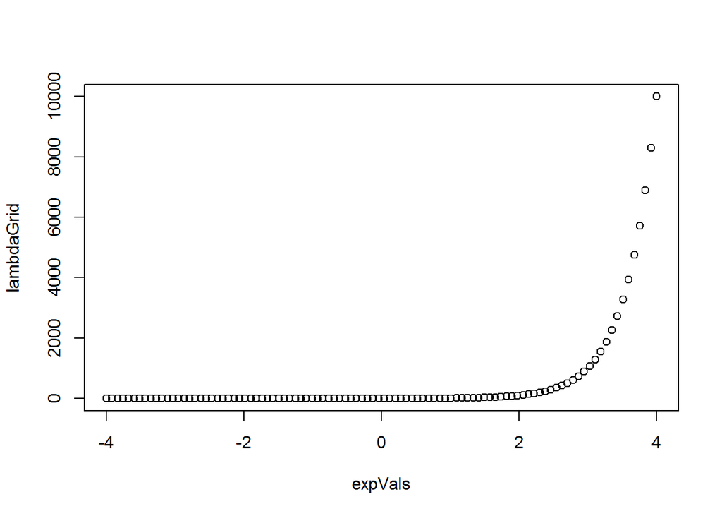

```r
# Ridge Regression
# build the matrices of variables in the format that glmnet wants
xNumericTrain.mat <- data.matrix(numericTrain.df[,1:49])
yNumericTrain.mat <- data.matrix(numericTrain.df[,50])
xNumericTest.mat <- data.matrix(numericTest.df[,1:49])
yNumericTest.mat <- data.matrix(numericTest.df[,50])

# want a "grid" of lambda vals so that we can pick an ideal lambda
numLambda <- 100
expVals <- seq(-4, 4, length = numLambda)
lambdaGrid <- 10^expVals
plot(expVals, lambdaGrid) # make sure that it looks exponential
```

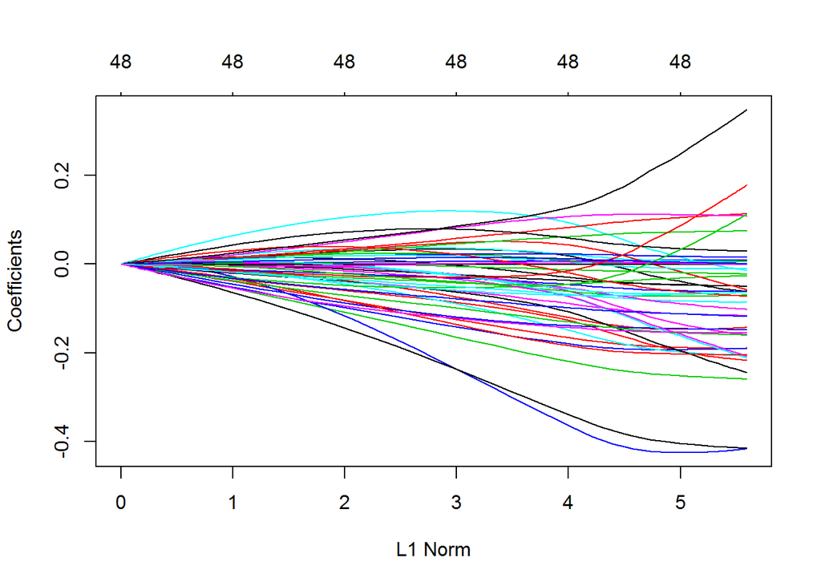

```r
ridgeModel <- glmnet(xNumericTrain.mat, yNumericTrain.mat, alpha = 0, lambda = lambdaGrid, intercept = TRUE) # use the lambdas that we just made to find the ideal value
plot(ridgeModel) # see what the model looks like
```

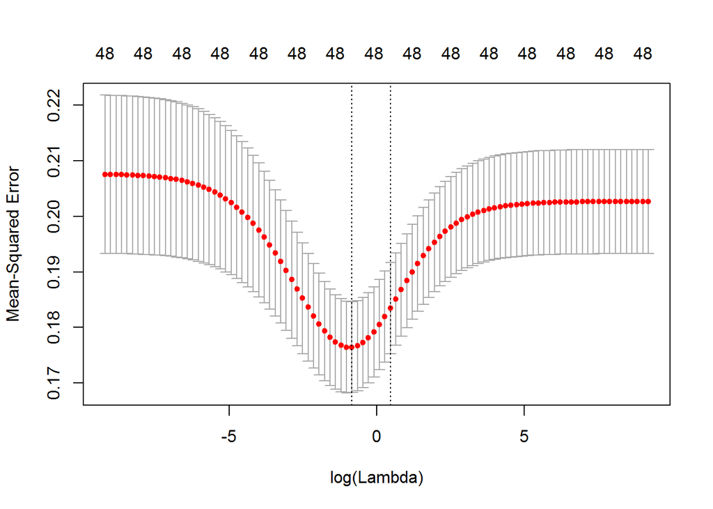

```r
# get the optimal lambda
crossValidatedRidgeModel <- cv.glmnet(xNumericTrain.mat, yNumericTrain.mat, alpha = 0, lambda = lambdaGrid, intercept = TRUE) # cross validate
plot(crossValidatedRidgeModel)
```

```r
(lambda0 <- crossValidatedRidgeModel$lambda.min)
```

```
## [1] 0.4328761
```

```r
(lambda1 <- crossValidatedRidgeModel$lambda.1se)
```

```
## [1] 1.592283
```

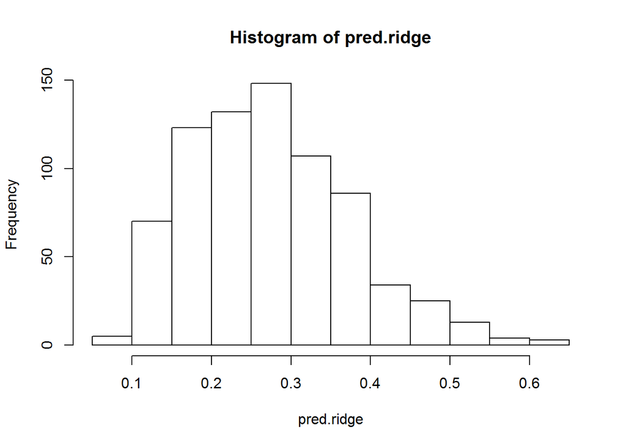

```r
mod.ridge <- glmnet(xNumericTrain.mat, yNumericTrain.mat, alpha = 0, lambda = lambda0, family = "binomial", intercept = TRUE) # use the optimal lambda

mod.ridgeConservative <- glmnet(xNumericTrain.mat, yNumericTrain.mat, alpha = 0, family = "binomial", lambda = lambda1, intercept = TRUE) # a more conservative estimate, for comparison

coef.ridge <- coef(mod.ridge)
coef.ridgeConservative <- coef(mod.ridgeConservative)

# And finally, the mse
pred.ridge <- predict(mod.ridge, newx = xNumericTest.mat, type="response")
hist(pred.ridge) # make sure it's between 0 and 1
```

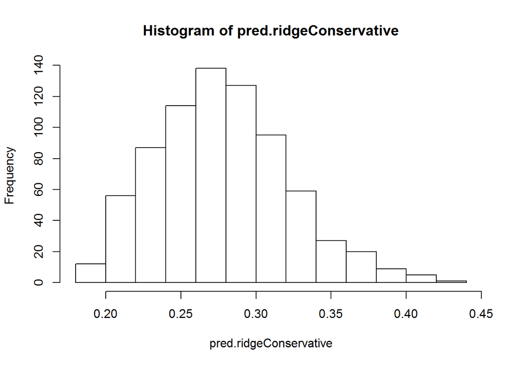

```r
pred.ridgeConservative <- predict(mod.ridgeConservative, type="response", newx = xNumericTest.mat)
hist(pred.ridgeConservative)
```

```r
mse.ridge <- with(numericTest.df, mean((pred.ridge - yNumericTest.mat)^2))
mse.ridgeConservative <- with(numericTest.df, mean((pred.ridgeConservative - yNumericTest.mat)^2))

bestRidgeValue <- 9999999
maxThresh <- 100
ratesMatrixRidge <- matrix(ncol = 3, nrow = maxThresh)
for(i in 1:maxThresh) {
    threshold <- i / maxThresh # so that it's a decimal
    ridgeBinaryPrediction <- ifelse(pred.ridge > threshold, TRUE, FALSE)

    truePositivesRidge <- sum(numericTest.df$response == T)
    falsePositvesRidge <- sum(numericTest.df$response == F & ridgeBinaryPrediction == T)
    trueNegativesRidge <- sum(numericTest.df$response == F)
    falseNegativesRidge <- sum(numericTest.df$response == T & ridgeBinaryPrediction == F)
    correctPositivesRidge <- sum(numericTest.df$response == T & ridgeBinaryPrediction == T)

    totalValueRidge <- (falseNegativesRidge * costFalseNegative) + (falsePositvesRidge * costFalsePositive) - (correctPositivesRidge * costTruePositive)
    if(totalValueRidge < bestRidgeValue) { # if the current value is the best one, save it. if not, try the next thresh val
        bestRidgeValue <- totalValueRidge
        bestThreshValueRidge <- threshold
    }

    tpRateRidge <- correctPositivesRidge / truePositivesRidge
    fpRateRidge <- (truePositivesRidge - correctPositivesRidge) / trueNegativesRidge

    ratesMatrixRidge[i,] = c(threshold, tpRateRidge, fpRateRidge)
}

# Comparison of errors
c(mse.ridge, mse.ridgeConservative)
```

```
## [1] 0.1856273 0.1988778
```